# Exemple_PRA1_solucio_copia_per_a_HTML

[figure not shown]

M2.993 - Anàlisi de textos

Màster Universitari en Ciència de Dades

Estudis d'Informàtica, Multimèdia i Telecomunicacions

# Processament i anàlisi d'informació textual (PRA1)

A la PRA1 treballarem amb un dataset de ressenyes (opinions o reviews) i ho analitzarem seguint un conjunt de tasques: des de la preparació i neteja de les dades, fins a l'avaluació de models de classificació de sentiments. Per tant, els objectius d‟aquesta activitat són:

- Aplicar tècniques de processament de llenguatge natural per a netejar i preprocessar les dades del dataset triat.
- Implementar algorismes d'aprenentatge automàtic, com ara LDA i classificació supervisada, per analitzar els textos de les ressenyes.
- Avaluar el rendiment dels models creats, utilitzant les mètriques adequades

Per tant, en aquesta primera pràctica, revisarem i aplicarem els coneixements apresos als mòduls 2, 3 i 4 de l'assignatura. Concretament tractarem 5 temes.

- 1. Elecció i preparació del dataset (10%).
- 2. Obtenció de dades (30%).
- 3. Detecció de temes (30%).
- 4. Classificació automàtica d'opinions positives i negatives (20%).
- 5. Avaluació de models de classificació (10%).

Mitjançant aquesta pràctica s'il·lustra com:

1. Descobrir trets característics d'un conjunt de ressenyes de productes d'*Amazon*
2. Classificar automàticament una opinió com a positiva o negativa amb mètodes de *machine learning*.

```python
import warnings
warnings.filterwarnings('ignore', category=DeprecationWarning)
warnings.filterwarnings('ignore', category=FutureWarning)
warnings.filterwarnings('ignore', category=UserWarning)

!pip install gensim     # Instal·lar si necessari.
```

# 1. Elecció i preparació del dataset

## 1.1. Descripció i càrrega del dataset

**Exercici 1.1.1:** En paraules, descriure el títol del dataset seleccionat, l'adreça original (font), i una descripció del mateix.

#############################################

SOLUCIÓ:

#############################################

- Título: Amazon Review Data
- Fuente: https://raw.githubusercontent.com/pycaret/pycaret/master/datasets/amazon.csv

Per a aquest exemple, utilitzarem un conjunt de les ressenyes disponibles en un dataset de Amazon*, el qual conté opinions realitzades pels clients sobre diferents productes de software de l'empresa.

**Ejercicio 1.1.2**: Càrrega del dataset i descripció de les seves principals característiques: mida, estructura, distribució de classe/ràting, distribució de longituds de text. A més, realitzar l'exploració preliminar del text de les opinions **orientada a descobrir potencials tasques de neteja a realitzar**.

**Important**: En cas d'haver triat un dataset sense una columna que denoti el sentiment de cada text, però sí el rating, en aquest exercici afegir una nova columna de sentiment. Per exemple, si tenim els valors 1 a 5 per a rating, podríem considerar els valors de 1 i 2, com a sentiment negatiu (0), i els valors 4 i 5 com a positiu (1). Per ara, ens centrarem en la classificació binària, per tant, no cal considerar els valors de sentiment “neutral” o rating=3

```python
import pandas as pd
# Carreguem l'arxiu de ressenyes a df :
```

```
Mida del dataset (20000, 2)
```

|  | reviewText | Positive |
| --- | --- | --- |
| 10650 | this app is great, especially when i get stuck... | 1 |
| 2041 | Doesn't work that great on my Kindle fire. Wha... | 0 |
| 8668 | Was a bit hard to find out how to search. But ... | 1 |
| 1114 | This ap is easy to use and I use it often when... | 1 |
| 13902 | You can enjoy the thrill of slots and a coin g... | 1 |

El dataset conté 20.000 instàncies.

Pel que fa a l'estructura del dataset, aquest té 2 atributs:

- **reviewText**: text de la ressenya.
- **Positive**: variable binària que indica si la ressenya és positiva o no.

Ara farem diverses exploracions i visualitzacions per anar comprenent el dataset i detectar les possibles tasques de neteja a realitzar.

- Grafiquem un histograma per a tenir una idea de la distribució de les ressenyes numèriques i veure el percentatge de cada classe.

| Positive | proportion |
| --- | --- |
| 1 | 76.165 |
| 0 | 23.835 |

**dtype:** float64

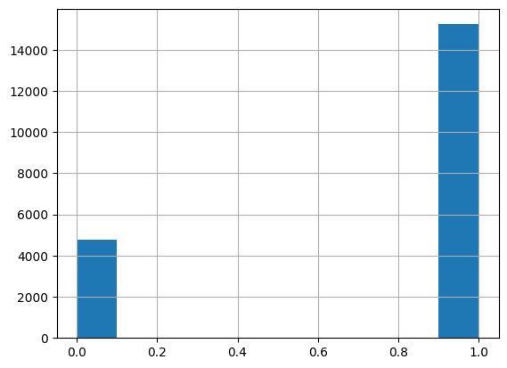

```python
# Graficar histograma


# Distribució de qualificacions per sentiment:
```

Com observem a l'histograma, hi ha més qualificacions positives que negatives. Segons la taula de distribució, aprox. 3 de cada 4 clients d'Amazon han fet comentaris positius als productes de programari o tecnologia.

- Grafiquem la longitud de les paraules de cada ressenya:

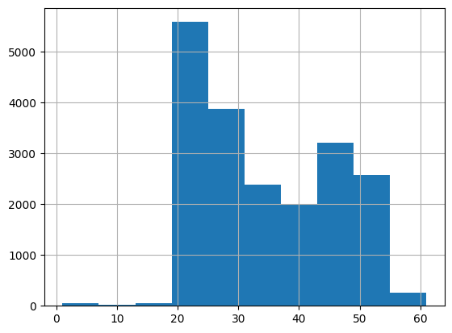

```python
# Grafiquem la longitud de les paraules de cada ressenya:
```

A partir de l'histograma anterior, observem que hi ha ressenyes amb text molt curt, inferior a 8 paraules.

```python
#Ressenyes molt curtes:
```

|  | reviewText | Positive | length |
| --- | --- | --- | --- |
| 378 | silly and lots of fun | 1 | 5 |
| 637 | the younger kids like it alot | 1 | 6 |
| 766 | fun | 1 | 1 |
| 823 | Love the birds!! | 1 | 3 |
| 879 | I can't get enough Angry BIRDS! | 1 | 6 |
| 1023 | Bleh | 0 | 1 |
| 1242 | Great App! Easy to use. Incredible selection. | 1 | 7 |
| 1337 | Fun to tweet. | 1 | 3 |
| 1572 | works great | 1 | 2 |
| 1734 | Good app and well made. | 1 | 5 |
| 1894 | not for me | 0 | 3 |
| 2091 | very good so much | 1 | 4 |
| 2117 | Fun in the car! | 1 | 4 |
| 2670 | Great stories! | 1 | 2 |
| 2733 | Thanks, works great | 1 | 3 |
| 3053 | Remove app from Digital Device | 1 | 5 |
| 3083 | didn't like | 0 | 2 |
| 3355 | #NAME? | 1 | 1 |
| 3465 | lame | 0 | 1 |
| 4224 | I enjoy playing the game to relax. | 1 | 7 |
| 4573 | Lots of fun! | 1 | 3 |
| 4965 | poor App | 0 | 2 |
| 4966 | Very helpful | 0 | 2 |
| 5084 | Like it! | 1 | 2 |
| 5399 | my daughter like it | 1 | 4 |
| 6541 | i hate this one | 0 | 4 |
| 7451 | I did not like it. | 0 | 5 |
| 8557 | Does not work on my Android. | 0 | 6 |
| 8945 | Awesome | 1 | 1 |
| 9190 | would never let me on there | 0 | 6 |
| 9446 | moms loves bingo | 1 | 3 |
| 10085 | Just getting started in reviewing this approach | 1 | 7 |
| 10745 | Makes a great list love it | 1 | 6 |
| 10853 | Great Deals | 1 | 2 |
| 11207 | Son loves this game | 1 | 4 |
| 11318 | Hilarious! | 1 | 1 |
| 11381 | Fun | 1 | 1 |
| 12727 | I use this all the time. | 1 | 6 |
| 15044 | Easy to scan! Super! | 1 | 4 |
| 15679 | A must for traveling | 1 | 4 |
| 16380 | No:( | 0 | 1 |
| 16383 | This is really fun. | 1 | 4 |
| 16389 | Too small. | 0 | 2 |
| 16454 | boring | 0 | 1 |
| 16456 | Great FAOTD... | 1 | 2 |
| 16507 | Best game | 1 | 2 |
| 16698 | Yawn | 0 | 1 |
| 16885 | Terrific | 1 | 1 |
| 16889 | Terrific 2 | 1 | 2 |
| 17194 | I love it. | 1 | 3 |
| 17366 | Uninstalled | 0 | 1 |
| 17464 | My 2 y/o loves it. | 1 | 5 |
| 19359 | excellent and easy to use. | 1 | 5 |
| 19368 | My favorite!!! | 1 | 2 |

```python
#Descartar ressenyes molt curtes:
```

[output not shown]

Ara explorem una mica més el text de les ressenyes per veure quines tasques de preparació hem de fer.

```python
# Expandir la visualització de la columna de ressenyes:
```

|  | reviewText | Positive | length |
| --- | --- | --- | --- |
| 15157 | I can't figure out how to enter account information for my google calendar / tasks account or my exchange calendar. Why would amazon pick this for the app of the day when there are millions of kindle … | 0 | 47 |
| 7759 | This is a great timer. You can have multiple timers saved. I love the trigger function. You set one timer to trigger another, start the first one and the second one starts as soon as the first one goe… | 1 | 49 |
| 10901 | I have shopped on Zappos for shoes for a couple of years now and have to say, I love it! I have also bought gift cards for my son who is hard to buy for so that makes it easier. Everything I have boug… | 1 | 56 |
| 12567 | MY BRAND NEW KINDLE FIRE HE GOT ALL MESSED UP FROM THIS APP AND WOULD RECOMMEND NOT! RISKING YOU KINDLE WITH THIS APP.. | 0 | 23 |
| 13132 | Good game....win or lose as much as any other game of poker......nice fast and efficient game on my Kindle. Kills time as well as any other. | 1 | 26 |

Com observem al dataset creat, algunes ressenyes tenen algunes paraules poc comunicatives (com "hdbddhd") i caràcters redundants (com "!"). En el següent apartat, implementarem totes les tasques de neteja que es requereixin per al dataset seleccionat.

## 1.2 Neteja de text

Abans de treballar amb els textos de les ressenyes, cal netejar-los. En general, depenent del dataset podria ser necessari:

1. Eliminar mencions (@), hashtags (#), o codi HTML.
2. Eliminar pàgines web.
3. Corregir paraules mal escrites (les que ressaltin al corpus).
4. Eliminar duplicats.
5. Convertir contraccions (per exemple, en lloc de wouldn't, es canviaria a would not).
6. Filtrar tokens no alfabètics.
7. Filtrar signes de puntuació (com ara: ";", ",", "!", "#", etc.) i treure espais dobles. Com a referència vegeu el codi de la PRA proporcionat (document *Exemple_PRA1.ipynb*); el codi elimina tots els signes de puntuació i a la cadena resultant li afegeix el signe ".", ens assegurem així que cada ressenya finalitzi amb aquest símbol; després s'usarà el "." per a crear la llista de sentències.
8. Convertir text a minúscules.

Per cada punt, fer les verificacions necessàries per determinar l'existència de cada element esmentat al punt anterior (mencions, hashtags, codi HTML, pàgines web, etc.) i implementar les accions de neteja (segons es requereixi).

**IMPORTANT**:

- Abans d'implementar qualsevol acció, se suggereix crear una columna, anomenada *text*, a partir del contingut de la columna de text original del dataset triat; i sobre la nova columna aplicar les tasques de neteja.
- Per cada acció de neteja realitzada, llistar almenys una ressenya que mostri que la funció implementada funciona. És a dir, presentar el text original i el text transformat (*text*).
- Afegir les cel·les de text i codi necessàries, de manera que es realitzin les verificacions suggerides, i es doni solució als problemes de qualitat de dades trobades. Com a orientació, es recomana revisar el fitxer **Exemple_PRA1.ipynb** per veure la millor manera d'organitzar la solució.

```python
#Crear la columna 'text' per aplicar-hi les tasques de preprocessament i neteja:
```

**Exercici:** Tractament de contraccions (una contracció és la forma abreujada d'una paraula, com "don't") a la seva forma completa (com "do not"). L'expansió de les contraccions pot ser útil per a millorar la identificació de 'stopwords'.  
**Sortida esperada:** Llistar una ressenya (*reviewText*), evidenciant que les contraccions han estat esteses (*text*).

```python
# Observem un text amb contraccions ("don't", "it's"):

# En aquest cas, sí que cal implementar un mecanisme d'extensió de contraccions, una forma és fer servir el paquet 'contractions'.
```

|  | reviewText | Positive | length | text |
| --- | --- | --- | --- | --- |
| 5 | This is a very entertaining game! You don't have to be smart to play it. I guess that's why I like it...it's easy and fun and that's what games are suppose to be. Be warned: this game is highly addict… | 1 | 40 | This is a very entertaining game! You don't have to be smart to play it. I guess that's why I like it...it's easy and fun and that's what games are suppose to be. Be warned: this game is highly addict… |

```python
#############################################
# SOLUCIÓ                                   #
#############################################

!pip install contractions

import contractions
```

|  | 5 |
| --- | --- |
| reviewText | This is a very entertaining game! You don't have to be smart to play it. I guess that's why I like it...it's easy and fun and that's what games are suppose to be. Be warned: this game is highly addict… |
| text | This is a very entertaining game! You do not have to be smart to play it. I guess that is why I like it...it is easy and fun and that is what games are suppose to be. Be warned: this game is highly ad… |

**dtype:** object

**Exercici:** Treure certs signes de puntuació.  
**Sortida esperada:** Llistar una ressenya original (*reviewText*), i el text modificat (*text*).

```python
import string, re

# Llistar una ressenya original (reviewText), i el text modificat (text).
```

|  | 4320 |
| --- | --- |
| reviewText | I love this app! It is very helpful! I really like to just play around with the scanner! :) If I were you I would download! You can always uninstall!!!!!! :) |
| text | I love this app It is very helpful I really like to just play around with the scanner If I were you I would download You can always uninstall . |

**dtype:** object

Finalment, observem a l'exemple que hi ha espais dobles, així que crearem una funció per eliminar-los:

```python
import re
```

```
'This is good if you like physics games free games or bird games Not like free version on ipod You get all the levels and the only adds pop up in the corner and are barely noticeable .'
```

# 2. Obtenció de dades

En aquesta part analitzarem el text, trobarem el conjunt de termes multiparaula rellevants del dataset i analitzarem l'objecte i aspectes de les opinions del text utilitzant el model Word2Wec. Per això començarem calculant els **millors bigrames i trigrames de les opinions del dataset** i els avaluarem segons les mètriques PMI i Likehood.

Posteriorment, detectarem els **n-grames que compleixin un patró sintàctic d'un sintagma nominal** (e.g: adjectiu + nom en singular/plural, nom + nom i nom en singular/plural) i acabarem **detectant col·locacions** amb un model de detecció basat en el mòdul `Phraser` de Gensim.

Un cop analitzats els termes multiparaula, **crearem un model word2vec** amb les opinions lematitzades i l'utilitzarem per analitzar els targets de les opinions.

```python
%%capture

# Per a aquest apartat cal carregar les llibreries següents:
import nltk
nltk.download('all')
from nltk import pos_tag, word_tokenize
from nltk.collocations import *
```

```python
#Importar la llista de stopwords a l'idioma dels *reviews* de la llibreria NLTK i afegim algunes addicionals:
```

```
['would',
 'a',
 'about',
 'above',
 'after',
 'again',
 'against',
 'ain',
 'all',
 'am',
 'an',
 'and',
 'any',
 'are',
 'aren']
```

### 2.1. Detecció de col·locacions

Les col·locacions són termes multiparaula, és a dir, seqüències de paraules que, en conjunt, tenen un significat que difereix significativament del significat de cada paraula individual (e.g. "free version" o "new york").

**Exercici 2.1.1:** Calcular els millors bigrames i trigrames de les opinions. Dels millors bigrames i trigrames, escull els que no comencen, ni acaben amb una stopword.

**Sortida esperada:** Imprimir els primers 20 n-grams obtinguts amb cada mètrica.

**Passos a realitzar**:

- Obtenir els tokens del text de les opinions i etiquetar-los pel seu PoS
- Aplicar les mètriques PMI i Likehood Ratio per a calcular els millors bigrames i els millors trigrames a partir dels tokens etiquetats que no comencen ni acaben amb una stopword.

*Primer pas*: Obtenir els tokens del text de les ressenyes. Etiqueta aquests tokens pel seu PoS.

Utilitza els mètodes *word_tokenize* per tokenitzar el text de les ressenyes i *pos_tag* per determinar l'etiqueta de cada token.  
**Sortida esperada:** Imprimeix els deu primers tokens, amb la seva respectiva etiqueta:

Abans de categoritzar els tokens pel seu tag POS, primer convertirem el text a minúscules:

```python
#Creem text en minúscula que reculli totes les ressenyes.
```

```
'this is a one of the best apps acording to a bunch of people and i agree it has bombs eggs pigs tnt king pigs and realustic stuff. this is a pretty good version of the game for being free there are lots of different levels to play my kids enjoy it a '
```

```python
#############################################
# SOLUCIÓ PAS 1                           #
#############################################
```

```
[('this', 'DT'), ('is', 'VBZ'), ('a', 'DT'), ('one', 'NN'), ('of', 'IN'), ('the', 'DT'), ('best', 'JJS'), ('apps', 'NN'), ('acording', 'VBG'), ('to', 'TO')]
```

*Segon pas*: Calcular els 300 millors bigrames i els 300 millors trigrames a partir dels tokens etiquetats (e.g. [(we, PRP), ...]) del text. Utilitza les mètriques PMI i Likehood Ratio.  
**Condició**: De la llista de millors bigrames i trigrames, escull els que no comencen ni acabin amb una stopword o bé amb termes que no aportin significat. Per al filtratge de stopwords considera:

- La llista de stopwords prèviament carregada (des del paquet NLTK), i
- Les categories POS que representen paraules buides com ara determinants, preposicions, entre d'altres.

**Sortida esperada:** Imprimeix els primers 20 n-grams obtinguts amb cada mètrica.

Recordeu la classificació d'etiquetes PoS.

**Etiquetes PoS**

- DT: Determinant
- JJ: Adjectiu
- NN: Nom en singular
- NNS: Nom en plural
- VBD: Verb en passat
- VBG: Verb en gerundi
- MD: Verb modal
- IN: Preposició o conjunció subordinada
- PRP: Pronom
- RB: Adverbi
- RP: Partícula
- CC: Conjunció coordinada
- CD: Numeral

```python
# Carreguem les mètriques per al càlcul de bigrames i trigrames:

bigram_measures = nltk.collocations.BigramAssocMeasures()
trigram_measures = nltk.collocations.TrigramAssocMeasures()

##############################################
# SOLUCIÓ PAS 2 #
##############################################
```

```
BEST BIGRAMS AND TRIGRAMS PMI
	 ['aback jdndnx', 'abd dictionarys', 'abdullah yusuf', 'absoltue fab', 'acquiant yoursel', 'adam graham', 'adams adventure', 'addison minich', 'adj jhddj', 'adolph hitler', 'advertisers shazam', 'agepeoples pleas', 'ah la', 'aha ahaahaa', 'airship module=shame', 'alec remark', 'alice christine', 'a…

BEST BIGRAMS AND TRIGRAMS LIKEHOOD RATIO
	 ['kindle fire', 'angry birds', 'alarm clock', 'works great', 'year old', 'fire hd', 'free version', 'highly recommend', 'highly recommend', 'free app', 'great app', 'keep track', 'much fun', 'blah blah', 'works well', 'works perfectly', 'kindle fire', 'long time', 'fun game', 'love this app']
```

**Exercici 2.1.2:** Detectar n-grames que compleixen el patró sintàctic d'un sintagma nominal (e.g: adjectiu + nom en singular/plural, nom + nom i nom en singular/plural). Les paraules components de cada n-grama han d'estar separades per un guió baix "_".  
**Sortida esperada:** Llista dels 20 primers n-grames que compleixin el patró sintàctic especificat, per exemple, 'new_york' i 'tourism'.

```python
#############################################
# SOLUCIÓ                                  #
#############################################
```

```
['one', 'apps', 'bunch', 'people', 'eggs', 'pigs', 'pigs', 'realustic_stuff', 'good_version', 'game', 'lots', 'different_levels', 'kids', 'lot', 'cool_game', 'bunch', 'levels', 'golden_eggs', 'super_fun', 'silly_game']
```

**Exercici 2.1.3:** Detectar col·locacions amb un model de detecció de frases, amb el mòdul Phraser de Gensim. Entrenar el model amb totes les opinions.

**Passos a realitzar**:

1. Crear la llista de `sentences`. Prendre com a referència el codi comentat que consta a la cel·la següent.
2. Entrenar el model de detecció de col·locacions usant `Phraser` de Gensim i convertir les ressenyes en una llista de `phrases` segons Gensim.

**Desenvolupament**:

*Primer pas*: Crear la llista de `sentences`.

```python
# Crear la llista de 'sentences'.
```

```
['This is a one of the best apps acording to a bunch of people and I agree it has bombs eggs pigs TNT king pigs and realustic stuff',
 'This is a pretty good version of the game for being free There are LOTS of different levels to play My kids enjoy it a lot too ',
 'this is a really cool game there are a bunch of levels and you can find golden eggs super fun ',
 'This is a silly game and can be frustrating but lots of fun and definitely recommend just as a fun time ',
 'This is a terrific game on any pad Hrs of fun My grandkids love it Great entertainment when waiting in long lines',
 'This is a very entertaining game You do not have to be smart to play it I guess that is why I like it it is easy and fun and that is what games are suppose to be Be warned this game is highly addictive ',
 'this is awesome and you do not need wi ti to play trust me it is really fun and addicting there are like 100 levels it is even free do not waste your money on the expensive one I mean seriously get the app',
 'this is awesome I bet no one even reads the reviews because they know this game is so good that they do not need to',
 'This is basicly the free version but with ads That is actually awesome It is addicting and free at the same time really I would reccomend it ',
 'this is by far the best free app that is available anywhere it has helped pass the time when nothing else would do do not pass this one up PS I hate this 20 word minimum ']
```

*Segon pas*: Entrenar el model de detecció de col·locacions usant `Phraser` de Gensim i convertir les ressenyes en una llista de *phrases* denominada `opinion_phrases_no_stopwords`.

Condicions:

- Les paraules de cada expressió multiparaula han d'estar separades amb un guió baix (_).
- Les `phrases` no han de ser stopwords; ni han de començar ni acabar amb stopwords. Utilitza la llista de stopwords per al filtratge.

**Sortida esperada**:

Llista de les 20 primeres `phrases` que no siguin, o no continguin stopwords.

```python
from gensim.models.phrases import Phraser
from gensim.models import Phrases

#############################################
# SOLUCIÓ PAS 2                           #
#############################################
```

```
['apps',
 'acording',
 'people',
 'bombs',
 'eggs',
 'pigs',
 'tnt',
 'king',
 'pigs',
 'realustic',
 'stuff',
 'pretty_good',
 'game',
 'different_levels',
 'enjoy',
 'really_cool',
 'game',
 'find',
 'golden_eggs',
 'super_fun']
```

## 2.2 Vectorització de paraules i termes amb Word2Vec

Abans de desenvolupar els exercicis, cal importar gensim i treure espais del text.

```python
# Importar el paquet gensim, que implementa un mètode per entrenar models Word2Vec.

import gensim

# Treure espais del text:
```

```
['apps',
 'acording',
 'people',
 'bombs',
 'eggs',
 'pigs',
 'tnt',
 'king',
 'pigs',
 'realustic']
```

**Exercici 2.2.1:** Obtenir targets de les opinions i els seus aspectes utilitzant el model Word2vec.

**Sortida esperada:** Llista dels primers 15 termes que tinguin més relació semàntica amb el terme/aspecte seleccionat.  
Passos a realitzar:

1. Convertir les `phrases` de cada oració en un token.
2. Crear una *sentence stream* on tots els tokens de les oracions estiguin lematitzats. Els tokens no poden ser stopwords ni tenir un stopword al començament o al final.
3. Crear un model *word2vec* de les opinions lematitzades. Anomeneu el model *w2v_opinions*.
4. A partir del vocabulari del model *word2vec*, seleccionar possibles aspectes representatius de les opinions.

**Primer pas**: Convertir les `phrases` de cada oració en un token. Per completar aquest pas:

- A cada oració substituir els bigrames que són `phrases` per la forma tokenitzada (e.g: "This is one of the best apps apps according to a bunch of people and..." -> "This is one of the best_apps apps according to a bunch of people and...".
- En fer els passos anteriors, les col·locacions formaran part del vocabulari del model *word2vec* que generarem.

*Important:* El codi següent es pot prendre com a referència per completar aquest primer pas. Considereu que:

- *opinion_phrases_stripped_no_stopwords* és l'objecte creat en iniciar aquest apartat (2.2).
- *opinion_sentences* és la llista de *sentences* creada al primer pas de l'Exercici 2.1.3.

```python
from nltk.util import ngrams
```

```
provides_lots
```

```
'This is a pretty_good version of the game for being free There are LOTS of different_levels to play My kids enjoy it a lot too '
```

**Segon pas**: Crear una *sentence stream* on tots els tokens de les oracions estiguin lematitzats. Els tokens no poden ser stopwords ni tenir un stopword al començament o al final. Per simplificar la tasca, podem considerar que el lema d'una col·locació no canvia i el seu PoS és 'col'. (e.g: ['We run a top of the line system utilizing Windows 10 Pro'] -> [run', 'top', 'line', 'system', 'utilize', 'windows_pro']).  
**Sortida esperada:** Llista dels 10 primers tokens lematitzats (que no siguin, ni continguin stopwords).

```python
##############################################
# SOLUCIÓ #
##############################################
```

```
['pretty_good',
 'version',
 'game',
 'free',
 'lot',
 'different_levels',
 'play',
 'kid',
 'enjoy',
 'lot']
```

**Tercer pas**: Crear un model *word2vec* de les opinions lematitzades. El model s'ha de dir w2v_opinions.  
**Sortida esperada:** Mostrar la quantitat d'oracions usades al model (usa l'atribut `corpus_count`).

```python
#############################################
# SOLUCIÓ                                   #
#############################################
```

```
19946
```

**Quart pas**: A partir del vocabulari del model word2vec, seleccionar possibles aspectes de la ressenya (e.g: en un dataset sobre aplicacions de software, es podria destacar l'aspecte *desktop*) i llista els termes semànticament relacionats amb aquests aspectes segons aquest model.

```python
# Obtenir el vocabulari:
```

```python
##############################################
# SOLUCIÓ                                    #
##############################################
```

|  | Term | Distance |
| --- | --- | --- |
| 0 | play | 0.985006 |
| 1 | fun | 0.962510 |
| 2 | challenge | 0.944568 |
| 3 | level | 0.939330 |
| 4 | addict | 0.925915 |
| 5 | played | 0.921073 |
| 6 | think | 0.920760 |
| 7 | kid | 0.919975 |
| 8 | hour | 0.916132 |
| 9 | beaten | 0.908077 |
| 10 | great_game | 0.902711 |
| 11 | quest_mode | 0.899938 |
| 12 | mind_boggling | 0.899479 |
| 13 | strategic | 0.897850 |
| 14 | pimple | 0.895879 |

# 3. Detecció de temes

En aquesta part explorarem els temes detectats utilitzant *WordNet* i farem l'extracció de temes a partir de LDA.

## 3.1 Exploració dels temes amb WordNet

Per a accedir a *Wordnet*, utilitzeu la llibreria `nltk`.

```python
from nltk.corpus import wordnet as wn
```

**Exercici 3.1.1:** Comprovar si, segons *Wordnet*, hi ha aspectes que estan allunyats semànticament del sentit del target, encara que en el model *word2vec* siguin similars.

Calcular la similitud de *Wu and Palmer* entre el sentit de *wordnet* del terme elegit (i.e 'word.n.01') i alguns dels seus aspectes.  
**Sortida esperada:**

- Llista de dos termes que segons *Wordnet* no estiguin tan propers, i el seu respectiu resultat de similitud, i
- Llista dels mateixos termes que segons el model *word2vec* estan més propers.

```python
#############################################
# SOLUCIÓ                                   #
#############################################
```

```
Distancia semántica según Wordnet: game  y  play : 0.2857142857142857
game y play  son distantes según Wordnet
Distancia semántica según el modelo word2vec: game  y  play : 0.98500556
game y play  son más cercanos, semánticamente, en el modelo Word2vec
```

**Exercici 3.1.2:** Identificar els termes monoparaula del vocabulari de *word2vec* que no són a *Wordnet*. Filtrar els termes que siguin noms o adjectius.

Del conjunt de termes identificats, cal esmentar:

- Abreviatures o termes específics del domini o expressions típiques de l'argot. Per exemple, en un dataset sobre restaurants, podrien identificar-se termes com ara *yummy*.  
  **Sortida esperada:**
- Quantitat de termes que no consten a *Wordnet*.
- Llista els 20 primers termes monoparaula que no consten a *Wordnet*.
- Llista almenys 3 termes dels llistats que, siguin inherents al vocabulari propi del domini

```python
#############################################
# SOLUCIÓ                                   #
#############################################
```

```
Quantitat de termes:  605

Termes de les opinions que no estan a Wordnet
 ['app', 'apps', 'quot', 'apos', 'anyone', 'everything', 'something', 'anything', 'everyone', 'others', 'etc', 'youtube', 'uninstalled', 'lol', 'faotd', 'facebook', 'dev', 'uninstall', 'alot', 'customizable']

Abreviatures i expressions típiques de l'argot del domini: app, uninstalled, youtube, facebook
```

## 3.2. LDA

Aquest apartat té com a objectiu comparar diferents models LDA i triar el més adequat de manera justificada.

**Passos a seguir:**

**Primer pas**: Convertir les opinions transformades (opinion_sentences_transformed) en llistes de noms i col·locacions. Això és necessari ja que els noms i les col·locacions expressen els temes de les opinions (e.g: [['This is a one of the best_apps according to the people opinions') -> ['one', 'best_apps', 'according' , 'people', 'opinion'].

```python
# Primer pas apartat 3.2
```

```
[['one', 'apps', 'bunch', 'people', 'egg', 'pig', 'king', 'pig', 'stuff'],
 ['pretty_good', 'version', 'game', 'different_levels', 'kid', 'lot'],
 ['really_cool', 'game', 'bunch', 'level', 'golden_eggs', 'super_fun'],
 ['game', 'lot', 'fun', 'definitely_recommend', 'fun', 'time'],
 ['game', 'fun', 'grandkids_love', 'great_entertainment', 'long_lines'],
 ['entertaining_game', 'fun', 'game', 'game', 'highly_addictive'],
 ['wi', 'really_fun', '100_levels', 'money', 'one', 'app'],
 ['review', 'game'],
 ['free_version', 'ad', 'time'],
 ['best_free_app',
  'available_anywhere',
  'time',
  'nothing_else',
  '20_word_minimum'],
 ['great_game',
  '6_year_old_grand',
  'nephew',
  'trick',
  'configuration',
  'minute',
  'level'],
 ['time_consuming',
  'works_great',
  'kindle_fire',
  'really_like',
  'game',
  'btother'],
 ['like_physics',
  'game',
  'game',
  'bird_games',
  'free_version',
  'ipod',
  'level',
  'adds_pop',
  'corner'],
 ['game', 'boredom', '3_stars', 'every_level'],
 ['apps', 'world', 'angry_birds_games', 'passing_time']]
```

**Exercici 3.2.1:** Extreure temes a partir de les llistes de noms i col·locacions de cada oració transformada. A més, utilitza la llibreria *pyLDAvis* per visualitzar els tòpics del millor model que has trobat.

**Sortida esperada:**

```python
#Experiment 1: amb n1 tòpics:

##############################################
# SOLUCIÓ #
##############################################
```

```
WARNING:gensim.models.ldamodel:too few updates, training might not converge; consider increasing the number of passes or iterations to improve accuracy
```

```
[(0,
  '0.072*"app" + 0.013*"day" + 0.012*"phone" + 0.010*"thing" + 0.010*"alarm" + 0.010*"option" + 0.009*"apps" + 0.009*"great_app" + 0.009*"book" + 0.008*"application"'),
 (1,
  '0.119*"app" + 0.031*"time" + 0.013*"people" + 0.010*"kindle_fire" + 0.008*"waste" + 0.008*"day" + 0.007*"friend" + 0.007*"one" + 0.007*"thing" + 0.007*"sound"'),
 (2,
  '0.047*"app" + 0.022*"game" + 0.015*"way" + 0.013*"button" + 0.011*"thing" + 0.011*"others" + 0.009*"time" + 0.007*"animal" + 0.007*"quot" + 0.007*"station"'),
 (3,
  '0.062*"game" + 0.011*"control" + 0.010*"fun_game" + 0.009*"play" + 0.008*"farm" + 0.008*"gem" + 0.007*"time" + 0.007*"level" + 0.007*"day" + 0.007*"flight"'),
 (4,
  '0.073*"app" + 0.033*"kindle_fire" + 0.020*"phone" + 0.016*"apps" + 0.014*"program" + 0.010*"problem" + 0.009*"tablet" + 0.009*"kindle" + 0.009*"works_great" + 0.007*"keyboard"'),
 (5,
  '0.153*"game" + 0.031*"fun" + 0.022*"lot" + 0.015*"time" + 0.014*"puzzle" + 0.010*"great_game" + 0.009*"option" + 0.009*"level" + 0.008*"quot" + 0.008*"kid"')]
```

Fes servir la llibreria pyLDAvis per visualitzar els tòpics del millor model trobat.

```python
!pip install pyLDAvis

#Instal·lar la versió colles 1.5.3 si utilitzeu Google Colab com a entorn d'execució.
#!pip install pandes==1.5.3
```

```
Downloading pyLDAvis-3.4.1-py3-none-any.whl (2.6 MB)
   ━━━━━━━━━━━━━━━━━━━━━━━━━━━━━━━━━━━━━━━━ 2.6/2.6 MB 35.0 MB/s eta 0:00:00
Downloading funcy-2.0-py2.py3-none-any.whl (30 kB)
```

```python
import pyLDAvis.gensim

# Modelo 1: amb n1 topics:
```

[interactive chart not shown]

**Exercici opcional:** Prenent com a base els resultats de cada model LDA, calculeu les mètriques de qualitat anomenades *perplexitat* i *coherència*, les quals estan definides en el paquet gensim.  
Tant la perplexitat com la coherència són mètriques complementàries. Una perplexitat baixa indica que el model pot generalitzar bé noves dades, mentre que una alta coherència indica que els temes generats són interpretables i diferents entre si. Quan avaluem el rendiment d‟un model LDA, se suggereix triar models que evidenciïn un equilibri entre ambdues mètriques.  
Com indica l'enunciat, aquest exercici és opcional, però ha estat incorporat a la pràctica per si algú vol aprofundir una mica més en el tema. Les mètriques esmentades ens poden ajudar a tenir un criteri addicional per triar el model de temes més adequats. Per a una introducció bàsica d'aquest tema podrien revisar el post següent (https://medium.com/@iqra.bismi/topic-modelling-using-lda-fe81a2a806e0)  
**Sortida esperada:**

```python
import warnings
warnings.filterwarnings('ignore', category=DeprecationWarning)
warnings.filterwarnings('ignore', category=FutureWarning)
warnings.filterwarnings('ignore', category=UserWarning)
```

```python
#############################################
# SOLUCIÓ                                  #
#############################################
```

```
Perplexitat del model LDA1: 8.486641416831219

Coherència del model LDA1: 0.2589919588793107
```

# 4. Classificació automàtica d'opinions positives i negatives

L'objectiu d'aquesta part serà crear un classificador que permeti, donat un text, identificar la seva polaritat. Aquesta quarta part consta de dos exercicis.

## 4.1 Crear un classificador binari

**Passos a seguir:**

1. Crear dues llistes, una amb els textos preprocessats (columna `text`) i una altra amb les etiquetes de valoració (0 i 1).
2. Vectoritzar les opinions amb un vectoritzador `tf.idf`. Feu servir `word` com a `analyzer`.
3. Preparar el corpus d'entrenament i avaluació i entrenar el classificador amb *Logistic Regression*.
4. Utilitzar el model entrenat per predir la categoria 1 (positiu) o 0 (negatiu) de les opinions del conjunt de test i mostrar les paraules més informatives per a cada categoria.

**Desenvolupament**:  
*Primer pas*: Crear dues llistes. Una amb els textos preprocessats i una altra amb les etiquetes de valoració (0 i 1).  
**Sortida esperada:** Llista de les 3 primeres opinions.

```python
#############################################
# SOLUCIÓ                                   #
#############################################
```

```
['This is a one of the best apps acording to a bunch of people and I agree it has bombs eggs pigs TNT king pigs and realustic stuff.',
 'This is a pretty good version of the game for being free There are LOTS of different levels to play My kids enjoy it a lot too .',
 'this is a really cool game there are a bunch of levels and you can find golden eggs super fun .']
```

*Segon pas*: Vectoritzar les opinions amb un vectoritzador `tf.idf`. Usar `word` com a `analyzer`.

**Sortida esperada:** Imprimir la matriu dels vectors corresponents a les primeres 5 opinions.

```python
#############################################
# SOLUCIÓ                                   #
#############################################
```

```
array([[0., 0., 0., ..., 0., 0., 0.],
       [0., 0., 0., ..., 0., 0., 0.],
       [0., 0., 0., ..., 0., 0., 0.],
       [0., 0., 0., ..., 0., 0., 0.],
       [0., 0., 0., ..., 0., 0., 0.]])
```

*Tercer pas*: Preparar el corpus d'entrenament i avaluació, i entrenar el classificador amb Logistic Regression.  
**Sortida esperada:** Temps d'execució que comporta fer l'entrenament (fit()).

```python
#############################################
# SOLUCIÓ                                   #
#############################################
```

```
Temps d'execució: 18.07 segons
```

*Quart pas*: Utilitzar el model entrenat per a predir la categoria 1 (positiu) o 0 (negatiu) de les opinions del conjunt de test i mostrar les paraules més informatives per a cada categoria.  
**Sortida esperada:** Llista de les 10 paraules més informatives de cada categoria.

```python
#############################################
# SOLUCIÓ                                   #
#############################################
```

```
CLASSES 1/0 DEL CORPUS DE TEST:
===============
[1 1 1 ... 1 1 1]

FEATURES MÉS INFORMATIVES EN LES OPINIONS POSITIVES I NEGATIVES:
===============
0 -8.267694580328309 not
0 -5.393761562342793 waste
0 -4.978294393269965 deleted
0 -4.375136649609145 uninstalled
0 -4.184397202519506 stupid
0 -4.027085720049591 boring
0 -3.958066013626699 sucks
0 -3.706690706510101 useless
0 -3.586075459372808 worst
0 -3.2423128994749733 nothing
1 8.673830864479891 love
1 8.059728229521165 great
1 5.103979851621875 easy
1 4.911347036913677 awesome
1 4.649400328321932 best
1 4.627961348741537 fun
1 4.464949180417275 works
1 3.240682600653012 well
1 3.025252002509793 perfect
1 2.936799725546442 exactly
None
```

## 4.2: Identificar sobre quins aspectes es fan valoracions negatives.

**Passos a seguir:**

1. Triar dues paraules més informatives de la categoria 0 i un conjunt d'opinions en què apareguin aquestes paraules. Preprocessar les opinions traient els caràcters de salt de línia.
2. Utilitzar el diccionari d'opinions (arxiu AFINN-111) per a extreure la polaritat de cada opinió com a mitjana dels valors de les 'opinion words' del text.
3. Seleccionar opinions amb polaritat negativa que exemplifiquin els aspectes més mal valorats. En el document d'anàlisi comenta quins són aquests aspectes.

*Primer pas*: Triar les dues paraules més informatives de la categoria 0 i un conjunt d'opinions en què apareguin aquestes paraules. Preprocessar les opinions traient els caràcters de salt de línia.  
**Sortida esperada:** Llista de les 3 primeres opinions en què apareguin els termes seleccionats.

```python
#############################################
# SOLUCIÓ                                   #
#############################################
```

```
this is awesome and you do not need wi ti to play trust me it is really fun and addicting there are like 100 levels it is even free do not waste your money on the expensive one I mean seriously get the app.

 This was the 1st app I ever downloaded on my Kindle Fire and I LOVE it And you do not need wi fi to play it I think it is a great app and time waster .

 Angry People in my book Any moron who would waste their time playing azimuth slingshot and call it a cultural phenomenon is what is the word oh yes a moron Those 5 minutes I played this thing still scar me .
```

```python
#############################################
# SOLUCIÓ                                   #
#############################################
```

```
this is awesome and you do not need wi ti to play trust me it is really fun and addicting there are like 100 levels it is even free do not waste your money on the expensive one I mean seriously get the app.
	 1.8333333333333333
This was the 1st app I ever downloaded on my Kindle Fire and I LOVE it And you do not need wi fi to play it I think it is a great app and time waster .
	 1.3333333333333333
Watch out This is a very addicting game but it is very fun for all ages Good way to kill time or waste time .
	 0.75
```

*Tercer pas:* Seleccionar opinions amb polaritat negativa que exemplifiquin els aspectes pitjor valorats (utilitzar un llindar per a seleccionar les pitjors ressenyes). Comenta quins són aquests aspectes.  
**Sortida esperada:**

- Llista de les tres primeres opinions negatives.
- Explora els textos per a descobrir els aspectes pitjor valorats pels clients.

```python
#############################################
# SOLUCIÓ                                   #
#############################################
```

```
Angry People in my book Any moron who would waste their time playing azimuth slingshot and call it a cultural phenomenon is what is the word oh yes a moron Those 5 minutes I played this thing still scar me .
Do not really know the point of this game It is almost impossible to knock the stupid birds down Why waste your time on this one .
Unless you are 7 years old this is a very boring and hard to manuver application The game is redundant.
```

# 5. Avaluació: comparació de models i discussió de resultats

**Exercici 5.1:** Obtenir els resultats de les mètriques d'avaluació del classificador basat en *regressió logística*.

**Sortida esperada:** Mètriques de rendiment del model de regressió logística (per classe).

```python
##############################################
# SOLUCIÓ MODEL REGRESSIÓ LOGÍSTICA          #
##############################################
```

```
              precision    recall  f1-score   support

           0       0.87      0.66      0.75       983
           1       0.90      0.97      0.93      3007

    accuracy                           0.89      3990
   macro avg       0.88      0.82      0.84      3990
weighted avg       0.89      0.89      0.89      3990
```

**Exercici 5.2:** Obtenir també els resultats de les mètriques d'avaluació per a un classificador diferent. Per exemple, utilitzar *SVM*.  
**Sortida esperada:**

- Temps d'execució de l'entrenament (fit()).
- Mètriques de rediment del model *SVM* (per classe).

```python
#############################################
# SOLUCIÓ  MODEL SVM                       #
#############################################
```

```
Temps d'execució: 1647.15 segons
              precision    recall  f1-score   support

           0       0.85      0.75      0.80       983
           1       0.92      0.96      0.94      3007

    accuracy                           0.91      3990
   macro avg       0.89      0.85      0.87      3990
weighted avg       0.91      0.91      0.91      3990
```